# Tarea 1

Erick Zarza

18 de agosto de 2017

# Control 1

Estudio sobre el prestigio de la Ocupación en Canadá e Índice Socioeconómico de Duncan.

## 1. Análisis exploratorio de Datos

El conjunto de datos tiene los siguientes faltantes y observaciones duplicadas, respectivamente:

```
## OCUPACION EDUCACION   INGRESO   MUJERES PRESTIGIO     CENSO      TIPO
##         0         0         0         0         0         0         4
```

```
## [1] 0
```

Hay 4 faltantes y no ha duplicados, sin embargo hay 2 profesiones con la misma clave del censo

```
## [1]  7 72
```

```
##         OCUPACION EDUCACION INGRESO MUJERES PRESTIGIO CENSO TIPO
## 6      PHYSICISTS     15.64   11030    5.13      77.6  2113 prof
## 7      BIOLOGISTS     15.09    8258   25.65      72.6  2113 prof
## 71 SLAUGHTERERS.1      7.64    5134   17.26      25.2  8215   bc
## 72 SLAUGHTERERS.2      7.64    5134   17.26      34.8  8215   bc
```

El número total de faltantes es 4 de las 102 observaciones, por lo tanto la métrica de completitud indica que faltan el 3.92% de los datos y todos son de la variable “Tipo”, además que no hay duplicados.

Es de llamar la atención que el primer estudio se realizó con ingresos mayores de $\$3500$ y en los datos presentados hay 17 observaciones con un ingreso promedio menor a $\$3500$ :

```
##                    OCUPACION INGRESO
## 28             NURSING.AIDES    3485
## 36                   TYPISTS    3148
## 38          TELLERS.CASHIERS    2448
## 41               FILE.CLERKS    3016
## 42             RECEPTIONISTS    2901
## 45       TELEPHONE.OPERATORS    3161
## 52              SALES.CLERKS    2594
## 53                   NEWBOYS     918
## 54 SERVICE.STATION.ATTENDANT    2370
## 60                     COOKS    3116
## 63               BABYSITTERS     611
## 64                LAUNDERERS    3000
## 65                  JANITORS    3472
## 68              FARM.WORKERS    1656
## 73                   CANNERS    1890
## 75         TEXTILE.LABOURERS    3485
## 84     SEWING.MACH.OPERATORS    2847
```

## Detección visual de outliers

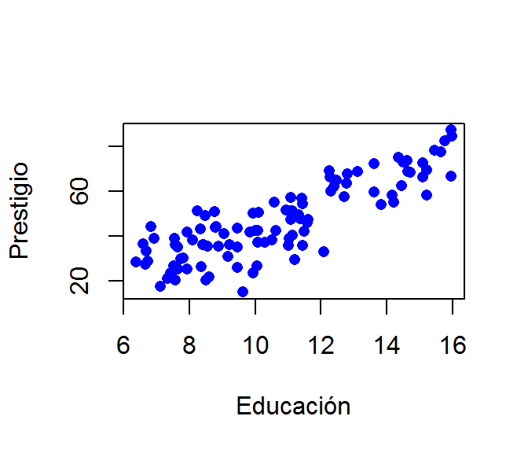

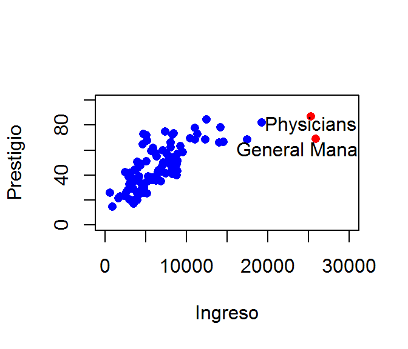

Las observaciones a las que les corresponde el punto rojo (probable outlier) en el comparativo de entre el Prestigio y el Ingreso son:

```
##           OCUPACION EDUCACION INGRESO MUJERES PRESTIGIO CENSO TIPO
## 2  GENERAL.MANAGERS     12.26   25879    4.02      69.1  1130 prof
## 24       PHYSICIANS     15.96   25308   10.56      87.2  3111 prof
```

```
##              OCUPACION EDUCACION INGRESO MUJERES PRESTIGIO CENSO TIPO
## 31 MEDICAL.TECHNICIANS     12.79    5180   76.04      67.5  3156   wc
```

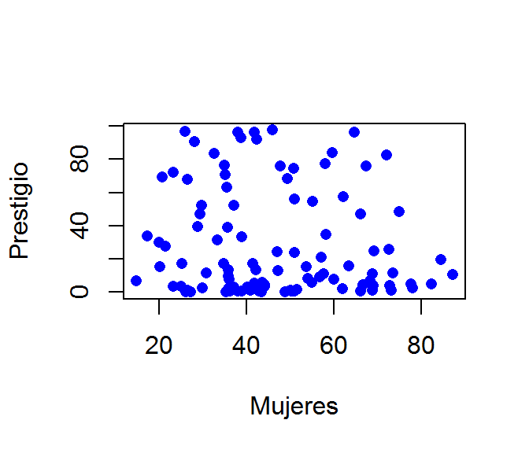

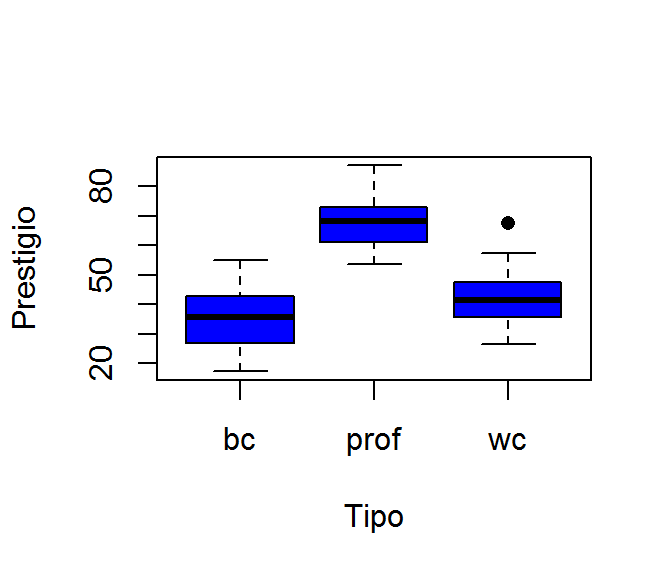

El posible outlier de “WC” es Medical Technicians.

El valor mínimo, primer cuartil, mediana, media 3er cuartil y máximo de cada variable es:

```
##    EDUCACION         INGRESO         MUJERES         PRESTIGIO
##  Min.   : 6.380   Min.   :  611   Min.   : 0.000   Min.   :14.80
##  1st Qu.: 8.445   1st Qu.: 4106   1st Qu.: 3.592   1st Qu.:35.23
##  Median :10.540   Median : 5930   Median :13.600   Median :43.60
##  Mean   :10.738   Mean   : 6798   Mean   :28.979   Mean   :46.83
##  3rd Qu.:12.648   3rd Qu.: 8187   3rd Qu.:52.203   3rd Qu.:59.27
##  Max.   :15.970   Max.   :25879   Max.   :97.510   Max.   :87.20
```

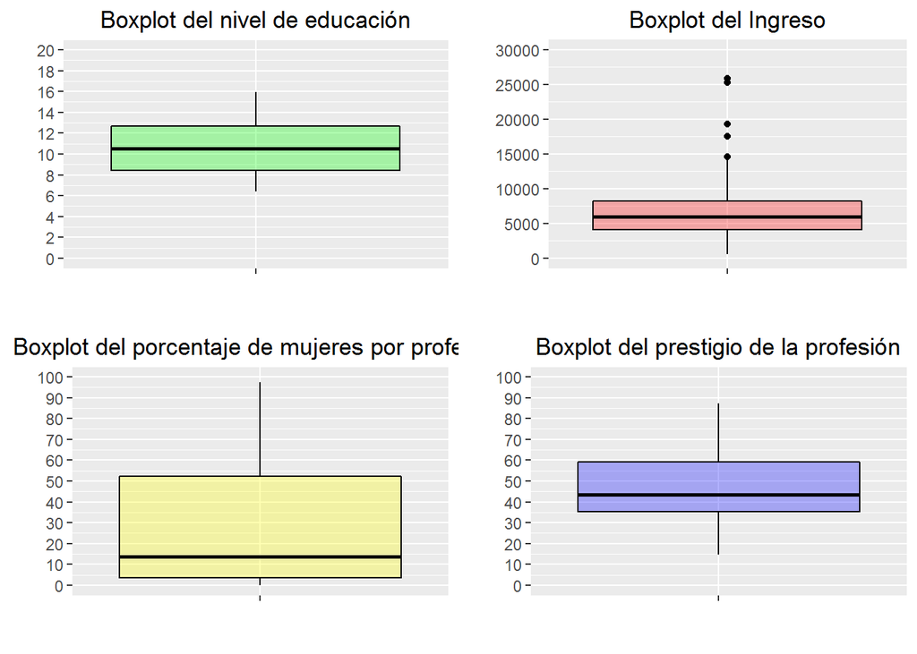

## 2. Clasificación de variables

```
## 'data.frame':    102 obs. of  7 variables:
##  $ OCUPACION: Factor w/ 102 levels "ACCOUNTANTS",..: 41 40 1 70 18 62 11 4 19 53 ...
##  $ EDUCACION: num  13.1 12.3 12.8 11.4 14.6 ...
##  $ INGRESO  : int  12351 25879 9271 8865 8403 11030 8258 14163 11377 11023 ...
##  $ MUJERES  : num  11.16 4.02 15.7 9.11 11.68 ...
##  $ PRESTIGIO: num  68.8 69.1 63.4 56.8 73.5 77.6 72.6 78.1 73.1 68.8 ...
##  $ CENSO    : int  1113 1130 1171 1175 2111 2113 2113 2141 2143 2153 ...
##  $ TIPO     : Factor w/ 3 levels "bc","prof","wc": 2 2 2 2 2 2 2 2 2 2 ...
```

Los datos contienen 7 variables distintas: Ocupación, educación, ingreso, mujeres, prestigio, censo, tipo. De las cuales las variables ocupación, censo y tipo son variables cualitativas; así como educación, mujeres y prestigio son del tipo cuantitativas continuas, e ingreso una variable cuantitativa discreta en este caso.

```
##             OCUPACION EDUCACION INGRESO MUJERES PRESTIGIO CENSO TIPO
## 1  GOV.ADMINISTRATORS     13.11   12351   11.16      68.8  1113 prof
## 2    GENERAL.MANAGERS     12.26   25879    4.02      69.1  1130 prof
## 3         ACCOUNTANTS     12.77    9271   15.70      63.4  1171 prof
## 4 PURCHASING.OFFICERS     11.42    8865    9.11      56.8  1175 prof
## 5            CHEMISTS     14.62    8403   11.68      73.5  2111 prof
```

```
##        OCUPACION EDUCACION INGRESO MUJERES PRESTIGIO CENSO TIPO
## 98   BUS.DRIVERS      7.58    5562    9.47      35.9  9171   bc
## 99  TAXI.DRIVERS      7.93    4224    3.59      25.1  9173   bc
## 100 LONGSHOREMEN      8.37    4753    0.00      26.1  9313   bc
## 101  TYPESETTERS     10.00    6462   13.58      42.2  9511   bc
## 102  BOOKBINDERS      8.55    3617   70.87      35.2  9517   bc
```

## 3. Explicación del prestigio respecto al nivel educativo

```
##
## Call:
## lm(formula = datbr$PRESTIGIO ~ datbr$EDUCACION)
##
## Coefficients:
##     (Intercept)  datbr$EDUCACION
##         -10.732            5.361
```

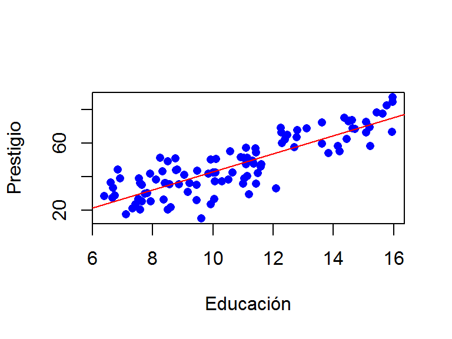

```
##
## Call:
## lm(formula = datbr$PRESTIGIO ~ datbr$EDUCACION)
##
## Residuals:
##      Min       1Q   Median       3Q      Max
## -26.0397  -6.5228   0.6611   6.7430  18.1636
##
## Coefficients:
##                 Estimate Std. Error t value Pr(>|t|)
## (Intercept)      -10.732      3.677  -2.919  0.00434 **
## datbr$EDUCACION    5.361      0.332  16.148  < 2e-16 ***
## ---
## Signif. codes:  0 '***' 0.001 '**' 0.01 '*' 0.05 '.' 0.1 ' ' 1
##
## Residual standard error: 9.103 on 100 degrees of freedom
## Multiple R-squared:  0.7228, Adjusted R-squared:   0.72
## F-statistic: 260.8 on 1 and 100 DF,  p-value: < 2.2e-16
```

Se puede observar que los resultados de graficar el prestigio y la educación por profesión, nos muestran la relación que existe entre ambas, puesto que mayor educación implica mayor prestigio. Considerando el modelo lineal de R, se rechaza la $H_{0}$ en favor de la $H_{1}$ para $\beta_{0}$ y $\beta_{1}$.

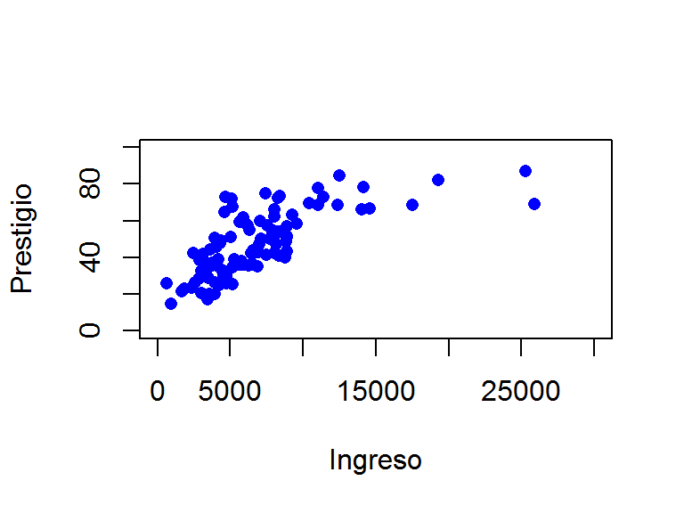

El prestigio parece que se puede explicar a través del ingreso. Ya que mientras mayor es el ingreso, tambien es mayor el prestigio.

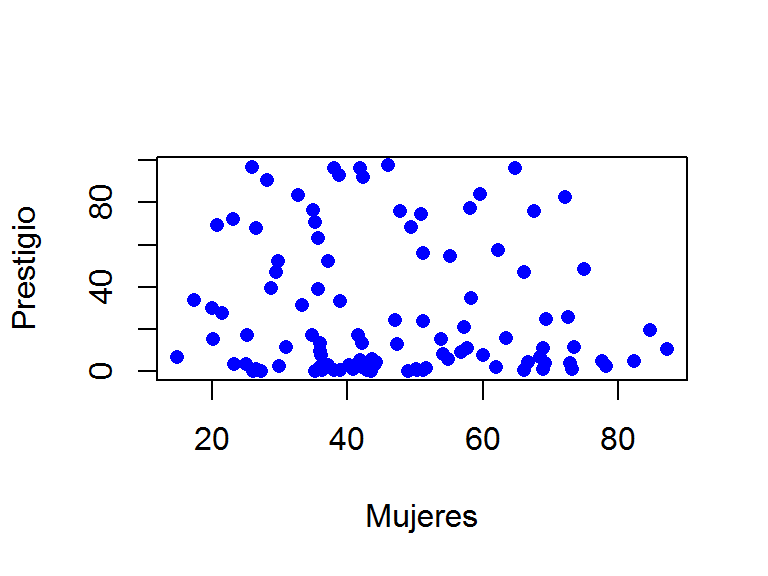